# Differences Weight Status in Youth Screen Time Percentage.

Gloria Grace

## Overview

The article can be found in: https://www.cdc.gov/nchs/data/databriefs/db157.pdf

Original visualization:

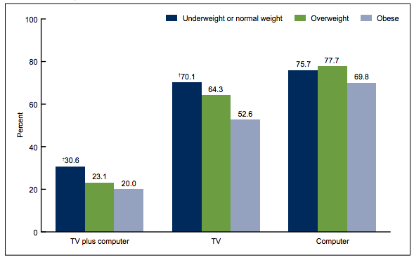

Claim:

“As weight status increased, the percentage of youth aged 12–15 who reported 2 hours or less of TV plus computer use decreased. Among underweight or normal-weight youth, 30.6% reported 2 hours or less of TV plus computer use daily compared with 23.1% and 20.0% for their overweight and obese peers, respectively. As weight status increased, the percentage of youth who watched TV for 2 hours or less daily decreased.

## Design

The visualization type that was chosen by the author is bar graph. Considering that the author is trying to compare how either TV or Computer or even both affected on a person weight status, by using a bar graph, if there are drastic differences with one another, it might be easy to tell which one is at the higher percentage than the other.

In the graph, the variable that are being shown are technology type, weight status, and percentage of people who use a technology for 2 hours daily.

The aesthetics that were chosen to represent the weight status is color. Dark blue represents people who are underweight or normal, green represents people who are overweight, and light blue represents the people who are obese.

The choice of making color as an aesthetic is appropriate because the color that are assigned between the weight status make it possible to differentiate each other when is next to one another.

## Data

### Data Overview

I was able to find the original data.

The data came from CDC/NCHS, National Health and Nutrition Examination Survey (NHANES) and NHANES National Youth Fitness Survey.

Data table can be accessed at: http://www.cdc.gov/nchs/data/databriefs/db157_table.pdf#4.

At the end of the research, it is stated in the copyright information that “All material appearing in this report is in the public domain and may be reproduced or copied without permission; citation as to source, however, is appreciated.”

For the weight samples, it accounts for the differential probabilities of selection, nonresponse, and noncoverage, were incorporated into the estimation process. The standard errors of the percentages were estimated using Taylor series linearization, a method that incorporates the sample design.

Both NHANES and NNYFS collected TV watching and computer use through a questionnaire administered in the home. Participants were then asked to attend a standardized physical examination in specially equipped mobile centers.

### Data Details

```r
weight_status <- read_csv("data/Weight Status.csv")
weight_status
```

```
## # A tibble: 9 × 7
##   Technology       `Weight Status`     N Percent    SE `95% CI...6` `95% CI...7`
##   <chr>            <chr>           <dbl>   <dbl> <dbl>        <dbl>        <dbl>
## 1 TV plus computer Underweight or…   469    30.6   2.4         25.4         35.8
## 2 TV plus computer Overweight        124    23.1   4.9         12.6         33.6
## 3 TV plus computer Obese             173    20     4           11.5         28.5
## 4 TV               Underweight or…   469    70.1   3.1         63.5         76.6
## 5 TV               Overweight        124    64.3   5.9         51.8         76.9
## 6 TV               Obese             173    52.6   3.4         45.2         60
## 7 Computer         Underweight or…   469    75.7   2.7         69.9         81.5
## 8 Computer         Overweight        124    77.7   3.2         70.8         84.7
## 9 Computer         Obese             173    69.8   4.4         60.4         79.3
```

The data has a total of 9 observations and 7 variables of column.

Each row represent the observation of the technology type, hours length of technology correlating with weight status.

There are 9 rows in total in the data set.

Knowing the relation between the usage length of youth’s screen time and their weight status might be quite interesting. Examining how long the usage affects weight status more specific also can be interesting, , the data set only categorized into three and limited to information of how various hours of usage can affect either more or less.

### Wrangling

To make the graph, I would have to filter out columns that are not relevant or variables that won’t be included in the graph.

```r
weight_status_wrangling <- weight_status %>%
  select(`Technology`, `Weight Status`, Percent) %>%
  arrange(desc(`Technology`))

weight_status_wrangling
```

```
## # A tibble: 9 × 3
##   Technology       `Weight Status`              Percent
##   <chr>            <chr>                          <dbl>
## 1 TV plus computer Underweight or normal Weight    30.6
## 2 TV plus computer Overweight                      23.1
## 3 TV plus computer Obese                           20
## 4 TV               Underweight or normal Weight    70.1
## 5 TV               Overweight                      64.3
## 6 TV               Obese                           52.6
## 7 Computer         Underweight or normal Weight    75.7
## 8 Computer         Overweight                      77.7
## 9 Computer         Obese                           69.8
```

I chose to select the columns that are only included in the graph from the original data to make it easier to focus on. I choose to arrange the data to make sure that I replicate the order the same as the original data.

## Replication

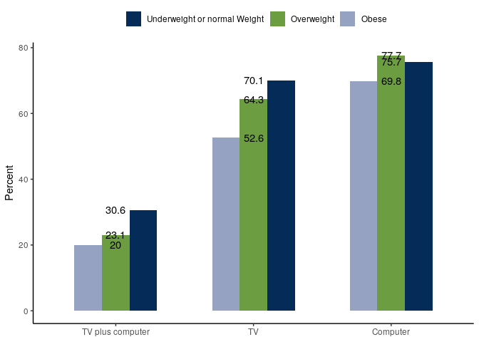

```r
weight_status_wrangling %>%
  ggplot(mapping = aes(x = Technology, y = Percent, fill = `Weight Status`)) +
  scale_fill_manual(values = c("Underweight or normal Weight" = "#052c59",
                               "Overweight" = "#6c9d41",
                               "Obese" = "#95a2c2"))+
  geom_col(position = "dodge", width = 0.6)+
  geom_text(aes(label = Percent))+
  scale_x_discrete(limits = c("TV plus computer", "TV", "Computer"))+
  labs(x = NULL, fill = NULL)+
  theme_classic()+
  theme(legend.position = "top")
```

There are a few difficulties I encountered. The first one is to use a position for geom colon because geom bar does not let two variables for it. It only allows either x or y axis. Then, I have to figure out how to position the legend to the top. I had to figure out how to color the graph specific to one type and to look for the rgb colors on it as well. I have to spend quite amount of time to arrange the graph too, I tried to modify it in the table but in the graph it won’t differs. I also could not figure out how to put numbers on top of each bar.

## Alternatives

### Design

One alternative design would be switching the technology type with the weight status whereas the original use their original graph to see how each technology connected to a person’s weight status. This alternative choice would allow me to discover a different claim. The changes can help to see which technology affected the weight status more, does it make a difference?

The other alternative design would be using facet grid to see more clearly of the difference between the technology with different weight statuses. The claim could be change because instead of looking at the number percentage of people that uses a technology, here would be looking at the weight status that might be affected by various technology type.

### Implementation

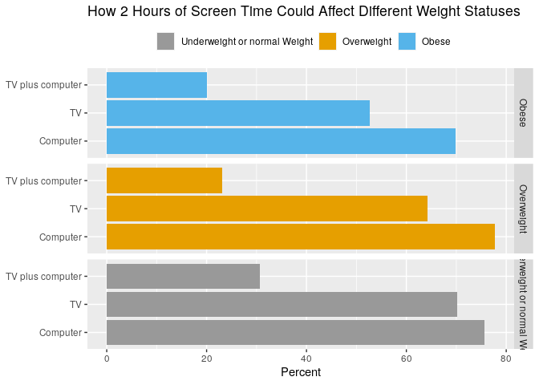

```r
weight_status_wrangling %>%
  ggplot(aes(x = Percent,y = Technology, fill = `Weight Status`))+
  scale_fill_manual(values = c("Underweight or normal Weight" = "#999999",
                               "Overweight" = "#E69F00",
                               "Obese" = "#56B4E9"))+
  geom_col(position = "dodge")+
  facet_grid(vars(`Weight Status`))+
  labs(y = NULL, fill = NULL,
       title = "How 2 Hours of Screen Time Could Affect Different Weight Statuses")+
  theme(legend.position = "top")
```

## Summary

I would say that I was partially success with my alternative design, I was hoping for people to be able to see the differences between picking TV, computer, or both and where has it have affect on each or not. As we can see from the graph, the differences are noticeable. Besides that, a thing that I want to figure out is the label “Underweight or normal weight” to be visible fully.

When gathering the data, do they calculate and gather everyone’s weight and height and also calculate to categorize a person’s weight status based on it to make the data that they have valid? If the hours were differ and add a new variable of watch hours, would there be significant changes in the weight status based on their screen time?

I would be interested if this data expanded into different screen time hours considering this data only gathers people who used technology for 2 hours daily where in predictive modeling maybe could predict how many hours affected a person’s daily routines or else.

This whole experience has been interesting and intriguing, I got to learn data wrangling and modeling more and understand it more as well. I got to learn how to upload and get a csv data from excel and make a visualization out of it as well. I enjoy this project because I can try different things to edit the graph and do things I never tried before.